# “Reproducible Research: Peer Assessment 1”

## Loading and Processing the data

```r
setwd("C:/Users/chuti/OneDrive/Desktop/Coursera/RepData_PeerAssessment1/activity")
rep_data_activity <- read.csv("activity.csv", header = TRUE, sep = ",")
dim(rep_data_activity)
```

```
## [1] 17568     3
```

```r
head(rep_data_activity)
```

```
##   steps       date interval
## 1    NA 2012-10-01        0
## 2    NA 2012-10-01        5
## 3    NA 2012-10-01       10
## 4    NA 2012-10-01       15
## 5    NA 2012-10-01       20
## 6    NA 2012-10-01       25
```

```r
summary(rep_data_activity)
```

```
##      steps                date          interval
##  Min.   :  0.00   2012-10-01:  288   Min.   :   0.0
##  1st Qu.:  0.00   2012-10-02:  288   1st Qu.: 588.8
##  Median :  0.00   2012-10-03:  288   Median :1177.5
##  Mean   : 37.38   2012-10-04:  288   Mean   :1177.5
##  3rd Qu.: 12.00   2012-10-05:  288   3rd Qu.:1766.2
##  Max.   :806.00   2012-10-06:  288   Max.   :2355.0
##  NA's   :2304     (Other)   :15840
```

## What is mean total number of steps taken per day?

### Calculate the total number of steps taken per day

```r
rep_data_activity$date <- as.Date(rep_data_activity$date, format="%Y-%m-%d")
total_mean <- aggregate(steps ~ date, rep_data_activity, sum, na.rm = TRUE)
str(total_mean)
```

```
## 'data.frame':    53 obs. of  2 variables:
##  $ date : Date, format: "2012-10-02" "2012-10-03" ...
##  $ steps: int  126 11352 12116 13294 15420 11015 12811 9900 10304 17382 ...
```

```r
head(total_mean)
```

```
##         date steps
## 1 2012-10-02   126
## 2 2012-10-03 11352
## 3 2012-10-04 12116
## 4 2012-10-05 13294
## 5 2012-10-06 15420
## 6 2012-10-07 11015
```

### Make a histogram of the total number of steps taken each day

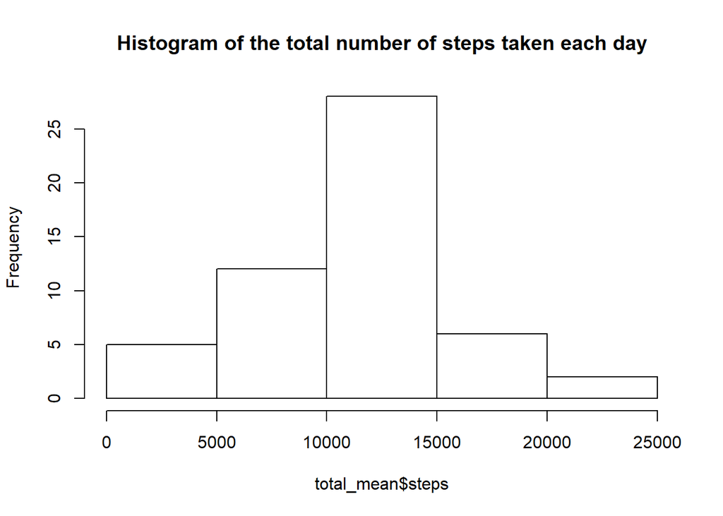

```r
knitr::opts_chunk$set(fig.width=12, fig.height=8, fig.path='Figs/',
                      echo=FALSE, warning=FALSE, message=FALSE)
hist(total_mean$steps, main = "Histogram of the total number of steps taken each day")
```

### Calculate and report the mean and median of the total number of steps taken per day

```r
summary(total_mean)
```

```
##       date                steps
##  Min.   :2012-10-02   Min.   :   41
##  1st Qu.:2012-10-16   1st Qu.: 8841
##  Median :2012-10-29   Median :10765
##  Mean   :2012-10-30   Mean   :10766
##  3rd Qu.:2012-11-16   3rd Qu.:13294
##  Max.   :2012-11-29   Max.   :21194
```

### Conclusion:

### mean of the total number of steps taken per day is 10766

### median of the total number of steps taken per day is 10765

## What is the average daily activity pattern?

### Make a time series plot (i.e. type=“l”) of the 5-minute interval (x-axis) and the average number of steps taken, averaged across all days (y-axis)

```r
knitr::opts_chunk$set(fig.width=12, fig.height=8, fig.path='Figs/',
                      echo=FALSE, warning=FALSE, message=FALSE)
total_steps <- aggregate(steps ~ interval, rep_data_activity, mean, na.rm = TRUE)
head(total_steps)
```

```
##   interval     steps
## 1        0 1.7169811
## 2        5 0.3396226
## 3       10 0.1320755
## 4       15 0.1509434
## 5       20 0.0754717
## 6       25 2.0943396
```

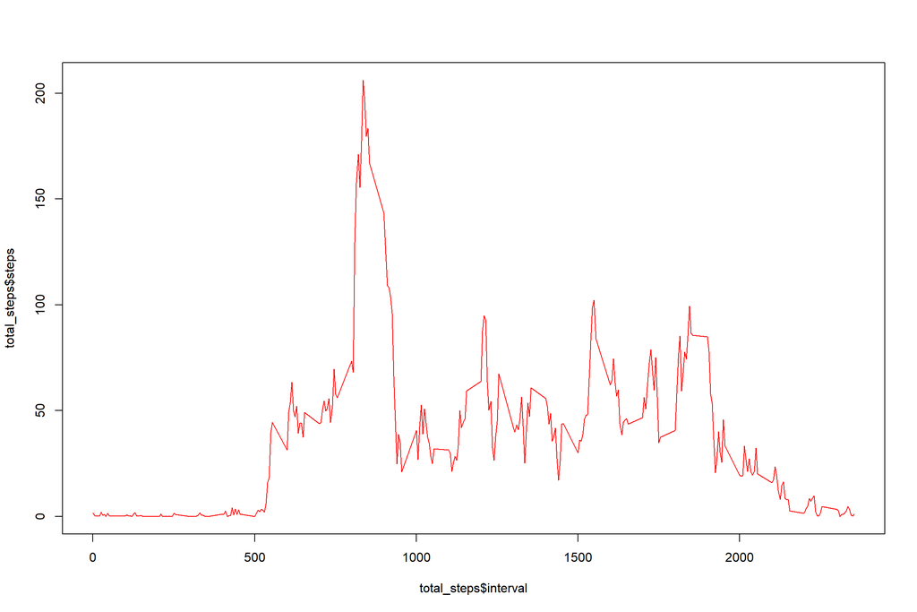

```r
plot(total_steps$steps ~ total_steps$interval, col = "red", type = "l")
```

### Which 5-minute interval, on average across all the days in the dataset, contains the maximum number of steps?

```r
max_5interval <- which.max(total_steps$steps)
max_5interval
```

```
## [1] 104
```

```r
total_steps[max_5interval, ]
```

```
##     interval    steps
## 104      835 206.1698
```

### Conclusion:

### The interval 835 has the maximum number of steps

## Imputing missing values

### Calculate and report the total number of missing values in the dataset (i.e. the total number of rows with NAs)

```r
sum(is.na(rep_data_activity))
```

```
## [1] 2304
```

### Conclusion:

### There are 2304 number of missing values in the database

### Devise a strategy for filling in all of the missing values in the dataset. The strategy does not need to be sophisticated. For example, you could use the mean/median for that day, or the mean for that 5-minute interval, etc.

### Create a new dataset that is equal to the original dataset but with the missing data filled in.

```r
setwd("C:/Users/chuti/OneDrive/Desktop/Coursera/RepData_PeerAssessment1/activity")
rep_data_activity_new <-  read.csv("activity.csv", header = TRUE, sep = ",")
rep_data_activity_new$steps[is.na(rep_data_activity_new$steps)] <- mean(rep_data_activity_new$steps, na.rm = TRUE)
head(rep_data_activity_new)
```

```
##     steps       date interval
## 1 37.3826 2012-10-01        0
## 2 37.3826 2012-10-01        5
## 3 37.3826 2012-10-01       10
## 4 37.3826 2012-10-01       15
## 5 37.3826 2012-10-01       20
## 6 37.3826 2012-10-01       25
```

### Make a histogram of the total number of steps taken each day and Calculate and report the mean and median total number of steps taken per day. Do these values differ from the estimates from the first part of the assignment? What is the impact of imputing missing data on the estimates of the total daily number of steps?

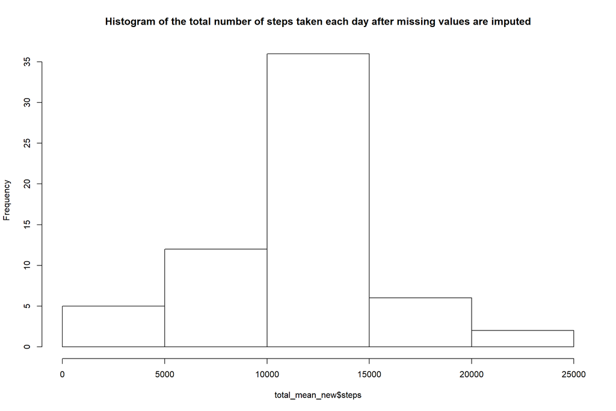

```r
knitr::opts_chunk$set(fig.width=12, fig.height=8, fig.path='Figs/',
                      echo=FALSE, warning=FALSE, message=FALSE)
total_mean_new <- aggregate(steps ~ date, rep_data_activity_new, sum, na.rm = TRUE)
hist(total_mean_new$steps, main = "Histogram of the total number of steps taken each day after missing values are imputed")
```

```r
summary(total_mean_new)
```

```
##          date        steps
##  2012-10-01: 1   Min.   :   41
##  2012-10-02: 1   1st Qu.: 9819
##  2012-10-03: 1   Median :10766
##  2012-10-04: 1   Mean   :10766
##  2012-10-05: 1   3rd Qu.:12811
##  2012-10-06: 1   Max.   :21194
##  (Other)   :55
```

### Conclusion:

### There is no big change in the mean and median of the total number of steps, after the missing values are replaced by the mean values

## Are there differences in activity patterns between weekdays and weekends?

### Create a new factor variable in the dataset with two levels - “weekday” and “weekend” indicating whether a given date is a weekday or weekend day.

```r
Weekday <- weekdays(as.Date(rep_data_activity_new$date))
head(weekdays)
```

```
##
## 1 function (x, abbreviate)
## 2 UseMethod("weekdays")
```

```r
tail(weekdays)
```

```
##
## 1 function (x, abbreviate)
## 2 UseMethod("weekdays")
```

```r
rep_data_activity_new$date_type <- ifelse(Weekday %in% c("Saturday", "Sunday"), "Weekend", "Weekday")
head(rep_data_activity_new)
```

```
##     steps       date interval date_type
## 1 37.3826 2012-10-01        0   Weekday
## 2 37.3826 2012-10-01        5   Weekday
## 3 37.3826 2012-10-01       10   Weekday
## 4 37.3826 2012-10-01       15   Weekday
## 5 37.3826 2012-10-01       20   Weekday
## 6 37.3826 2012-10-01       25   Weekday
```

### Make a panel plot containing a time series plot (i.e. type=“l”) of the 5-minute interval (x-axis) and the average number of steps taken, averaged across all weekday days or weekend days (y-axis). See the README file in the GitHub repository to see an example of what this plot should look like using simulated data.

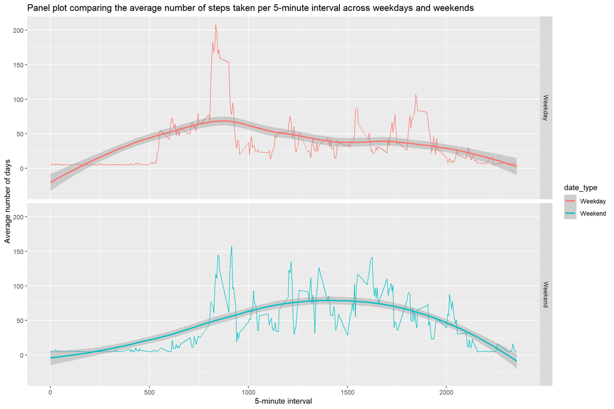

```r
knitr::opts_chunk$set(fig.width=12, fig.height=8, fig.path='Figs/',
                      echo=FALSE, warning=FALSE, message=FALSE)
library(ggplot2)
total_steps_new <- aggregate(steps ~ interval + date_type, rep_data_activity_new, mean)
ggplot(total_steps_new, aes(x = interval, y = steps, color = date_type)) + facet_grid(date_type~.) + geom_line() + labs(title = "Panel plot comparing the average number of steps taken per 5-minute interval across weekdays and weekends", y = "Average number of days", x = "5-minute interval") + geom_smooth()
```